# Decision Tree Lab

Aarthee Baskaran, Shipra Trivedi, Sarah Abourakty

May 5, 2021

Breast cancer data was used to train and test decision tree models for both single and multi-classification. In this lab, we will evaluate the accuracy of the models and offer recommendations on how to use this model in the real world.

# PR. status Decision Tree

Below, we generated the decision tree from the PR. status data (excluding ER. status)

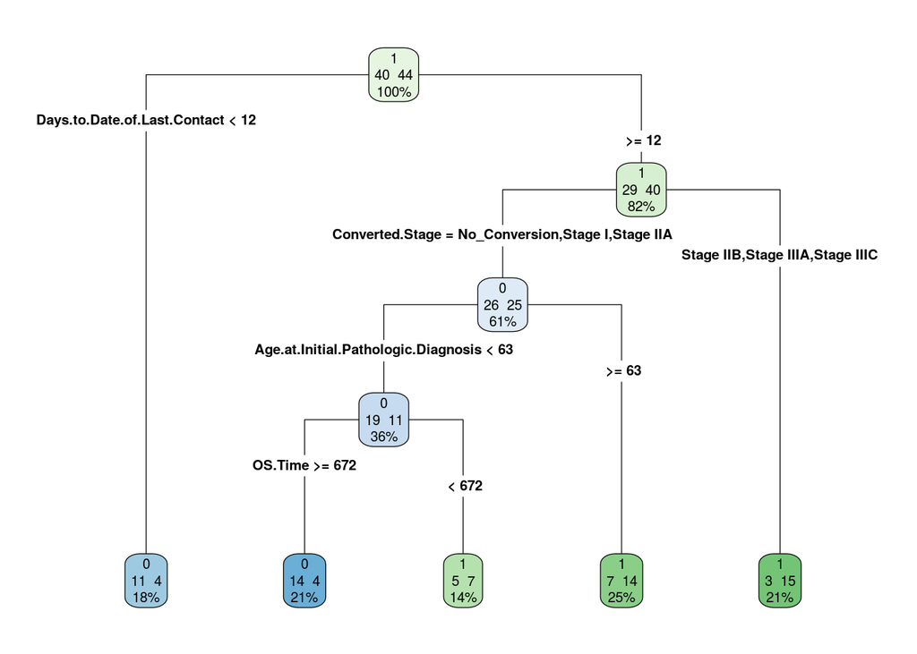

This figure produces an elbow chart of the tree size. It determines that the tree should have nodes based on where the mean is below the horizontal line, as observed above, based on the complexity parameter and standard deviation.

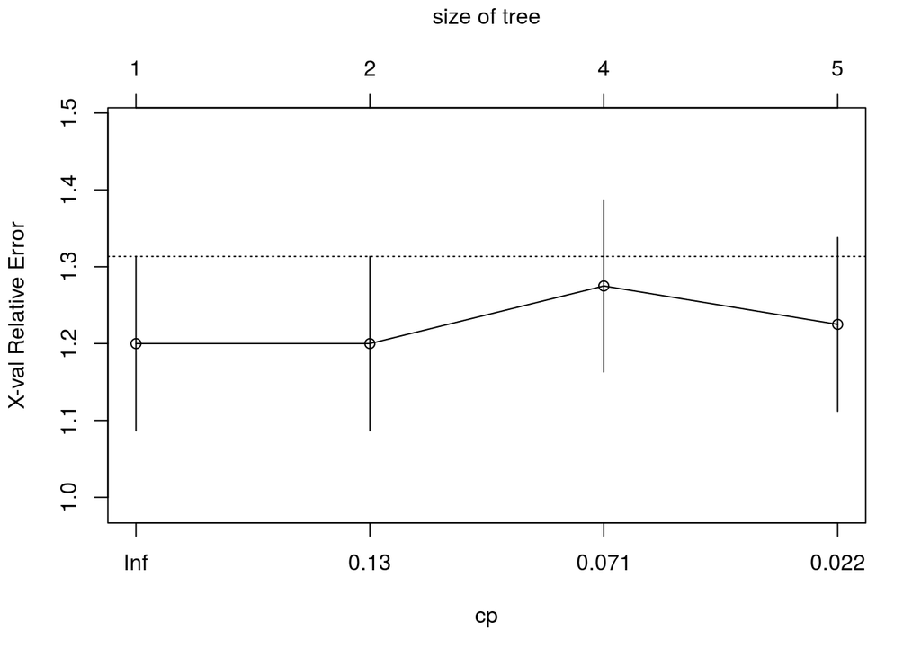

```
## Confusion Matrix and Statistics
##
##           Actual
## Prediction 0 1
##          0 6 2
##          1 5 8
##
##                Accuracy : 0.6667
##                  95% CI : (0.4303, 0.8541)
##     No Information Rate : 0.5238
##     P-Value [Acc > NIR] : 0.1371
##
##                   Kappa : 0.3408
##
##  Mcnemar's Test P-Value : 0.4497
##
##             Sensitivity : 0.8000
##             Specificity : 0.5455
##          Pos Pred Value : 0.6154
##          Neg Pred Value : 0.7500
##              Prevalence : 0.4762
##          Detection Rate : 0.3810
##    Detection Prevalence : 0.6190
##       Balanced Accuracy : 0.6727
##
##        'Positive' Class : 1
##
```

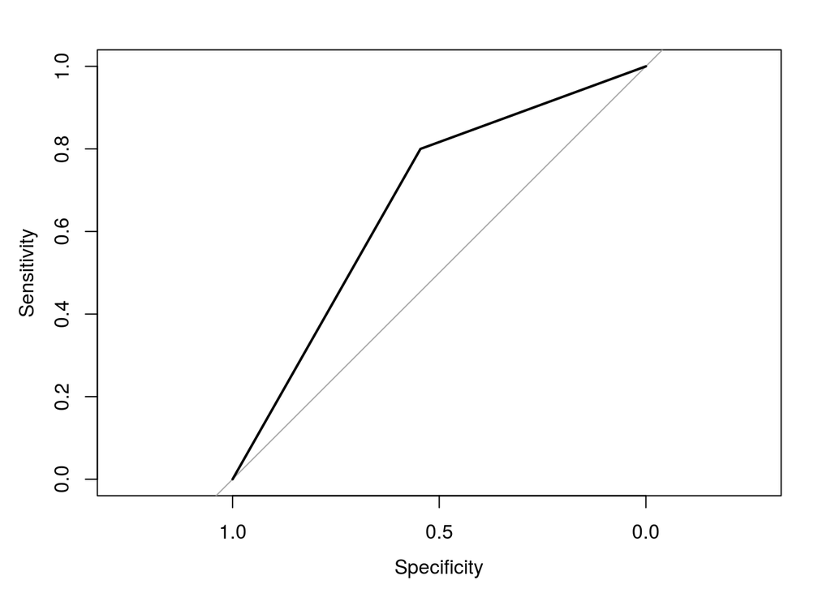

# Tumor Classification Decision Tree

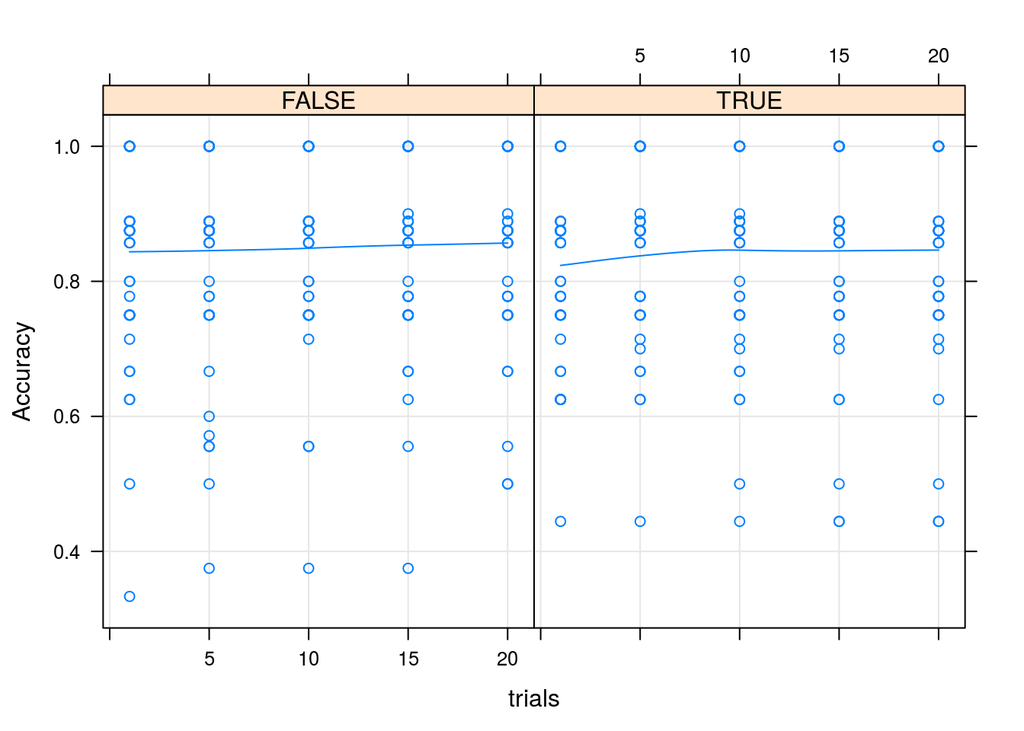

```
## Confusion Matrix and Statistics
##
##           Actual
## Prediction T1 T2 T3 T4
##         T1  2  0  0  0
##         T2  1 12  2  0
##         T3  0  1  1  0
##         T4  0  0  0  1
##
## Overall Statistics
##
##                Accuracy : 0.8
##                  95% CI : (0.5634, 0.9427)
##     No Information Rate : 0.65
##     P-Value [Acc > NIR] : 0.1182
##
##                   Kappa : 0.5833
##
##  Mcnemar's Test P-Value : NA
##
## Statistics by Class:
##
##                      Class: T1 Class: T2 Class: T3 Class: T4
## Sensitivity             0.6667    0.9231    0.3333      1.00
## Specificity             1.0000    0.5714    0.9412      1.00
## Pos Pred Value          1.0000    0.8000    0.5000      1.00
## Neg Pred Value          0.9444    0.8000    0.8889      1.00
## Prevalence              0.1500    0.6500    0.1500      0.05
## Detection Rate          0.1000    0.6000    0.0500      0.05
## Detection Prevalence    0.1000    0.7500    0.1000      0.05
## Balanced Accuracy       0.8333    0.7473    0.6373      1.00
```

This model is fairly accurate with a kappa value of 0.5833. The initial baserates for T1, T2, T3, and T4 were 0.143, 0.619, 0.181, and 0.057, respectively. This model predicted prevalence value for the above tumors classes as 0.15, 0.65, 0.15, and 0.05, respectively. This was observed with balanced accuracies of 0.833, 0.747, 0.637, and 1.

# Recommendations

*PR Status Classification Model*

We concluded that it was not the best model for predicting presence of breast cancer since the result cannot only depend on PR. status and other factors should be taken into account. We recommend that this model can be used as an aid in diagnostics but should not be the sole tool used.

*Tumor Classification Model*

Most of this dataset is comprised of patients with tumor 2 classes; if we had a dataset with more tumor classfications, the model’s predictive accuracy for the other classes can also be improved. We recommend that this model is used in conjuction with other diagnostic tools to breast cancer occurence in patients.